# Growth Curve Analysis, Part 3

Dan Mirman

22 May 2020

# Random effects

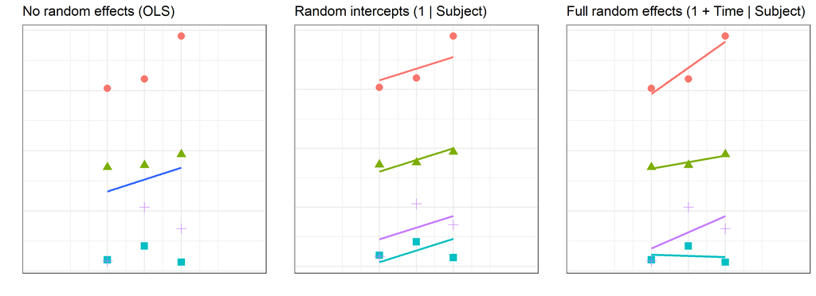

- *Keep it maximal*: A full or maximal random effect structure is when all of the factors that could hypothetically vary across individual observational units are allowed to do so.
- Incomplete random effects can inflate false alarms
- Full random effects can produce convergence problems (we’ll come back to this issue in a little while)

# Within-subject effects

Example: Target fixation in spoken word-to-picure matching (VWP)

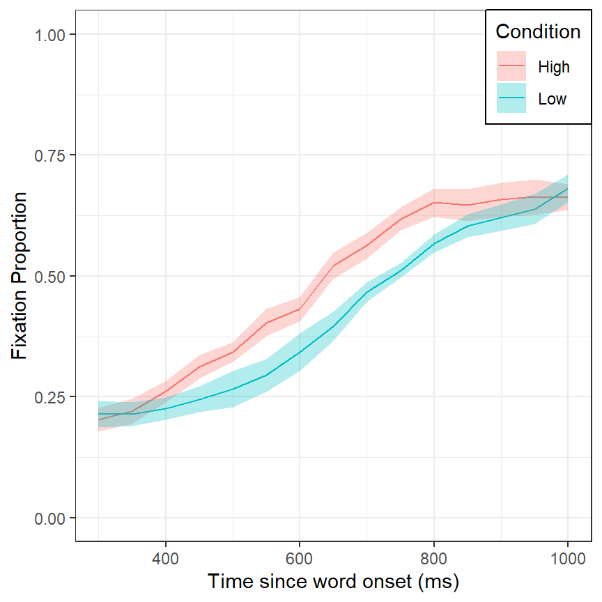

```r
ggplot(TargetFix, aes(Time, meanFix, color=Condition, fill=Condition)) +
  stat_summary(fun=mean, geom="line") +
  stat_summary(fun.data=mean_se, geom="ribbon", color=NA, alpha=0.3) +
  theme_bw() + expand_limits(y=c(0,1)) + legend_positioning(c(1,1)) +
  labs(y="Fixation Proportion", x="Time since word onset (ms)")
```

# Within-subject effects: prep for GCA

```r
TargetFix.gca <- code_poly(TargetFix, predictor="Time", poly.order=3)
```

[figure not shown]

```r
str(TargetFix.gca)
```

```
## 'data.frame':    300 obs. of  11 variables:
##  $ Subject   : Factor w/ 10 levels "708","712","715",..: 1 1 1 1 1 1 1 1 1 1 ...
##  $ Time      : num  300 300 350 350 400 400 450 450 500 500 ...
##  $ timeBin   : num  1 1 2 2 3 3 4 4 5 5 ...
##  $ Condition : Factor w/ 2 levels "High","Low": 1 2 1 2 1 2 1 2 1 2 ...
##  $ meanFix   : num  0.1944 0.0286 0.25 0.1143 0.2778 ...
##  $ sumFix    : num  7 1 9 4 10 5 13 5 14 6 ...
##  $ N         : int  36 35 36 35 36 35 36 35 36 35 ...
##  $ Time.Index: num  1 1 2 2 3 3 4 4 5 5 ...
##  $ poly1     : num  -0.418 -0.418 -0.359 -0.359 -0.299 ...
##  $ poly2     : num  0.4723 0.4723 0.2699 0.2699 0.0986 ...
##  $ poly3     : num  -0.4563 -0.4563 -0.0652 -0.0652 0.1755 ...
```

# Within-subject effects: fit full GCA model

```r
m.full <- lmer(meanFix ~ (poly1+poly2+poly3)*Condition + #fixed effects
                 (poly1+poly2+poly3 | Subject) + #random effects of Subject
                 (poly1+poly2+poly3 | Subject:Condition), #random effects of Subj by Cond
               data=TargetFix.gca, REML=F)
```

```
## boundary (singular) fit: see ?isSingular
```

```r
get_pvalues(m.full)
```

```
##                      Estimate Std..Error    df   t.value  Pr...t..  p.normal
## (Intercept)         0.4773228    0.01385 19.87 34.457856 3.383e-19 0.000e+00
## poly1               0.6385604    0.05994 17.27 10.654065 5.152e-09 0.000e+00
## poly2              -0.1095979    0.03849 19.99 -2.847535 9.954e-03 4.406e-03
## poly3              -0.0932612    0.02330 18.07 -4.001954 8.305e-04 6.282e-05
## ConditionLow       -0.0581122    0.01879 16.22 -3.093146 6.891e-03 1.980e-03
## poly1:ConditionLow  0.0003188    0.06579 15.70  0.004846 9.962e-01 9.961e-01
## poly2:ConditionLow  0.1635455    0.05393 19.08  3.032574 6.826e-03 2.425e-03
## poly3:ConditionLow -0.0020869    0.02705 16.67 -0.077163 9.394e-01 9.385e-01
##                    p.normal.star
## (Intercept)                  ***
## poly1                        ***
## poly2                         **
## poly3                        ***
## ConditionLow                  **
## poly1:ConditionLow
## poly2:ConditionLow            **
## poly3:ConditionLow
```

# Within-subject effects: random effects

```r
head(ranef(m.full)$"Subject")
```

```
##     (Intercept)    poly1      poly2     poly3
## 708  -0.0001522  0.01085 -0.0035635 -0.004929
## 712   0.0110222  0.10693 -0.0093253 -0.036517
## 715   0.0113775  0.11482 -0.0109566 -0.039652
## 720  -0.0020717 -0.01300 -0.0003714  0.003738
## 722   0.0138362  0.16223 -0.0200919 -0.058180
## 725  -0.0178395 -0.20733  0.0253549  0.074204
```

```r
head(ranef(m.full)$"Subject:Condition")
```

```
##          (Intercept)    poly1    poly2    poly3
## 708:High    0.012273 -0.13120 -0.12985  0.01515
## 708:Low    -0.061222  0.17039  0.06228  0.01232
## 712:High    0.021229  0.08290  0.02803  0.02002
## 712:Low    -0.014453  0.04483  0.03255 -0.01730
## 715:High    0.012361  0.05971  0.05517 -0.02500
## 715:Low    -0.008687  0.10599  0.13031 -0.03948
```

# Within-subject effects: random effects

```r
# str(ranef(m.full))
VarCorr(m.full)
```

```
##  Groups            Name        Std.Dev. Corr
##  Subject:Condition (Intercept) 0.0405
##                    poly1       0.1404   -0.43
##                    poly2       0.1124   -0.33  0.72
##                    poly3       0.0417    0.13 -0.49 -0.43
##  Subject           (Intercept) 0.0124
##                    poly1       0.1195    0.91
##                    poly2       0.0165   -0.42 -0.76
##                    poly3       0.0421   -0.85 -0.99  0.83
##  Residual                      0.0438
```

What is being estimated?

- Random variance and covariance
- Unit-level random effects (but constrained to have mean = 0)

*This is why df for parameter estimates are poorly defined in MLR*

# Alternative random effects structure

```r
m.left <- lmer(meanFix ~ (poly1+poly2+poly3)*Condition + #fixed effects
                ((poly1+poly2+poly3)*Condition | Subject), #random effects
              data=TargetFix.gca, REML=F)
```

```
## boundary (singular) fit: see ?isSingular
```

```r
get_pvalues(m.left)
```

```
##                      Estimate Std..Error     df   t.value  Pr...t..  p.normal
## (Intercept)         0.4773228    0.01679 10.003 28.436524 6.691e-11 0.000e+00
## poly1               0.6385604    0.05146 10.000 12.407713 2.133e-07 0.000e+00
## poly2              -0.1095979    0.03717 10.004 -2.948277 1.457e-02 3.196e-03
## poly3              -0.0932612    0.02063 10.039 -4.521487 1.095e-03 6.141e-06
## ConditionLow       -0.0581122    0.02110 10.005 -2.754110 2.033e-02 5.885e-03
## poly1:ConditionLow  0.0003188    0.07479  9.994  0.004263 9.967e-01 9.966e-01
## poly2:ConditionLow  0.1635455    0.06274 10.000  2.606797 2.618e-02 9.139e-03
## poly3:ConditionLow -0.0020869    0.03334 10.676 -0.062602 9.512e-01 9.501e-01
##                    p.normal.star
## (Intercept)                  ***
## poly1                        ***
## poly2                         **
## poly3                        ***
## ConditionLow                  **
## poly1:ConditionLow
## poly2:ConditionLow            **
## poly3:ConditionLow
```

# Alternative random effects structure

```r
# str(ranef(m.left))
# head(ranef(m.left)$"Subject")
VarCorr(m.left)
```

```
##  Groups   Name               Std.Dev. Corr
##  Subject  (Intercept)        0.0519
##           poly1              0.1570    0.18
##           poly2              0.1094   -0.29  0.03
##           poly3              0.0491   -0.28 -0.37  0.63
##           ConditionLow       0.0649   -0.89 -0.13  0.49  0.34
##           poly1:ConditionLow 0.2286    0.38 -0.46 -0.62  0.10 -0.56
##           poly2:ConditionLow 0.1889    0.20  0.08 -0.81 -0.22 -0.43  0.74
##           poly3:ConditionLow 0.0862   -0.08 -0.40 -0.06 -0.47  0.06 -0.27 -0.43
##  Residual                    0.0430
```

This random effect structure makes fewer assumptions:

- Allows unequal variances across conditions
- Allows more flexible covariance structure between random effect terms

# Alternative random effects structure requires more parameters

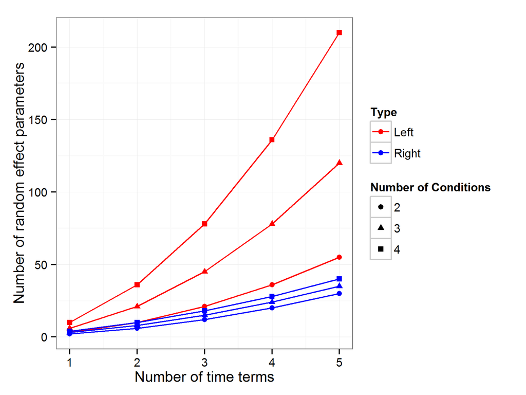

# Convergence problems

**Need to simplify random effects**

- Remove random effects of higher-order terms

```
Outcome ~ (poly1+poly2+poly3)*Condition + (poly1+poly2+poly3 | Subject)
Outcome ~ (poly1+poly2+poly3)*Condition + (poly1+poly2 | Subject)
```

- Remove correlation between random effects

```
Outcome ~ (poly1+poly2+poly3)*Condition + (1 | Subject) +
  (0+poly1 | Subject) + (0+poly2 | Subject) + (0+poly3 | Subject)
```

# Participants as fixed vs. random effects

**In general**, participants should be treated as random effects.

This captures the typical assumption of random sampling from some population to which we wish to generalize.

**Pooling**

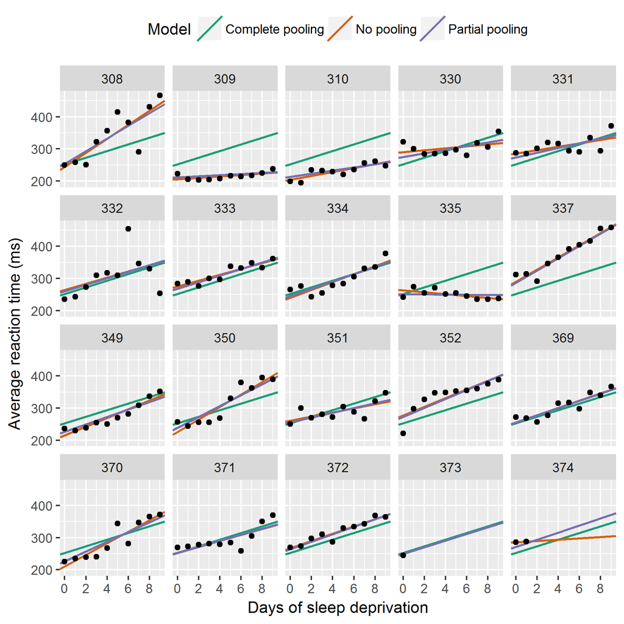

http://tjmahr.github.io/plotting-partial-pooling-in-mixed-effects-models/

# Participants as fixed vs. random effects

**In general**, participants should be treated as random effects.

This captures the typical assumption of random sampling from some population to which we wish to generalize.

**Shrinkage**

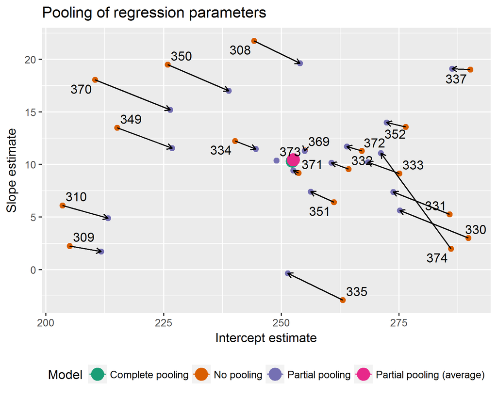

http://tjmahr.github.io/plotting-partial-pooling-in-mixed-effects-models/

# Participants as fixed vs. random effects

**In general**, participants should be treated as random effects.

This captures the typical assumption of random sampling from some population to which we wish to generalize.

**Exceptions are possible**: e.g., neurological/neuropsychological case studies where the goal is to characterize the pattern of performance for each participant, not generalize to a population.

# Lunch break; Exercise 3

`Az`: Use natural (not orthogonal) polynomials to analyze decline in performance of 30 individuals with probable Alzheimer’s disease on three different kinds of tasks - Memory, complex ADL, and simple ADL.

- Plot the observed data
- (Why are natural polynomials more useful for these data?)
- Prep the data for GCA
- Fit the GCA model(s)
- Interpret the results:
  - Which terms show significant effects of experimental factors?
  - To what extent do model comparisons and the parameter-specific p-values yield the same results?
- Plot observed and model fit data